# Case Study: Credit Prediction

MSBA7002: Business Statistics

## Introduction

Read:

- Chapter 6.1 and 2.2.1-2.2.2

Objectives:

1. Exploratory Data Analysis (EDA)
   - Abnormality (missing data, outliners, etc.)
   - Pairwise scatter plots
   - Correlation tables
   - Correlation heat-map
   - **Candidate variables and possible new variables**
2. Criterion of accuracy
   - **Prediction Error**
     - Cp: Mallows’s Cp
   - **Other targets**
     - AIC: Akaike Information Criterion
     - BIC: Bayesian Information Criterion
3. Model Building
   - All subset
   - Forward Selection
   - Backward Selection
   - Model Diagnostics
4. Findings and Reports
   - Final Report

## Case Study: Credit Prediction

- We will use ISLR’s credit card balance data named `Credit`.
- Credit: 12 variables about customers, including Income, Credit limit, and so on.

**Goal of the study:**

## 1. Exploratory Data Analysis (EDA)

As good Data Scientists, we must always first look at the data to identify potential problems. Here are some main things that you should be in the lookout for:

- Do we have a set of sensible variables?
- Abnormality in the data
- Make a set of candidates to be chosen from
  - make new variables
  - transformations on some variables

Additionally, just by looking at the data, we might gain significant insights for decision making. Finally, it’s easier for managers to understand plots than to understand p-values, and doing Exploratory Data Analysis (EDA) is a great way to practice producing meaningful plots!

### Take a quick look at the data

Pull out the information about the data: `Credit` is packaged in `ISLR`

How many customers (observations) and variables are contained in the data-set?

```r
dim(Credit)
```

```
## [1] 400  12
```

We have 400 customers (observations) and 12 variables.

Variable names

```r
names(Credit)
```

```
##  [1] "ID"        "Income"    "Limit"     "Rating"    "Cards"     "Age"
##  [7] "Education" "Gender"    "Student"   "Married"   "Ethnicity" "Balance"
```

Structure of the data

```r
str(Credit)
```

```
## 'data.frame':    400 obs. of  12 variables:
##  $ ID       : int  1 2 3 4 5 6 7 8 9 10 ...
##  $ Income   : num  14.9 106 104.6 148.9 55.9 ...
##  $ Limit    : int  3606 6645 7075 9504 4897 8047 3388 7114 3300 6819 ...
##  $ Rating   : int  283 483 514 681 357 569 259 512 266 491 ...
##  $ Cards    : int  2 3 4 3 2 4 2 2 5 3 ...
##  $ Age      : int  34 82 71 36 68 77 37 87 66 41 ...
##  $ Education: int  11 15 11 11 16 10 12 9 13 19 ...
##  $ Gender   : Factor w/ 2 levels " Male","Female": 1 2 1 2 1 1 2 1 2 2 ...
##  $ Student  : Factor w/ 2 levels "No","Yes": 1 2 1 1 1 1 1 1 1 2 ...
##  $ Married  : Factor w/ 2 levels "No","Yes": 2 2 1 1 2 1 1 1 1 2 ...
##  $ Ethnicity: Factor w/ 3 levels "African American",..: 3 2 2 2 3 3 1 2 3 1 ...
##  $ Balance  : int  333 903 580 964 331 1151 203 872 279 1350 ...
```

See the first 10 rows of the data

```r
head(Credit,10)
```

```
##    ID  Income Limit Rating Cards Age Education Gender Student Married
## 1   1  14.891  3606    283     2  34        11   Male      No     Yes
## 2   2 106.025  6645    483     3  82        15 Female     Yes     Yes
## 3   3 104.593  7075    514     4  71        11   Male      No      No
## 4   4 148.924  9504    681     3  36        11 Female      No      No
## 5   5  55.882  4897    357     2  68        16   Male      No     Yes
## 6   6  80.180  8047    569     4  77        10   Male      No      No
## 7   7  20.996  3388    259     2  37        12 Female      No      No
## 8   8  71.408  7114    512     2  87         9   Male      No      No
## 9   9  15.125  3300    266     5  66        13 Female      No      No
## 10 10  71.061  6819    491     3  41        19 Female     Yes     Yes
##           Ethnicity Balance
## 1         Caucasian     333
## 2             Asian     903
## 3             Asian     580
## 4             Asian     964
## 5         Caucasian     331
## 6         Caucasian    1151
## 7  African American     203
## 8             Asian     872
## 9         Caucasian     279
## 10 African American    1350
```

Let’s see if we have any missing values. This data doesn’t contain any missing values. It is great!

```r
sum(is.na(Credit))
```

```
## [1] 0
```

We copy the data out of `ISLR` and remove `ID` first.

```r
data.crd <- copy(Credit)
data.crd <- data.crd[,-1]
```

### Pairwise scatter plots

Let’s now take a quick look at the pairwise relationship.

First, we will use `dplyr` to filter the non-numeric columns. Then we will feed the output into our `ggpairs` function to produce the paired scatter-plots.

**WARNING: Running the pairwise scatter plots will take a while if you have many variables.**

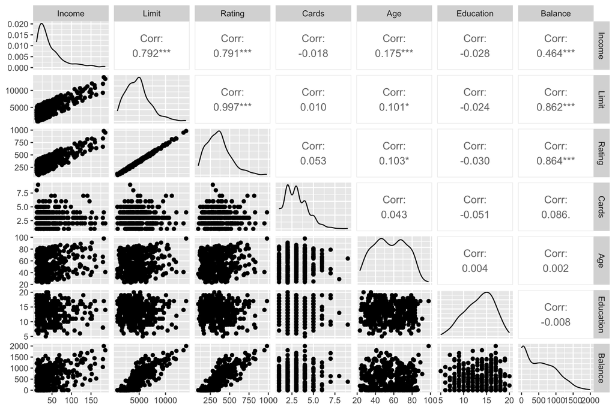

```r
data.crd %>%
  select_if(is.numeric)  %>%
  ggpairs(progress = FALSE)
```

### Correlation tables

Let’s look at the pairwise correlations among all quantitative variables. This will tell us which variable is highly correlated with the response and with each other.

```r
# pairwise cor's among all quantitative var's
data.crd %>%
  select_if(is.numeric)  %>%
  cor()
```

```
##                Income       Limit      Rating       Cards         Age
## Income     1.00000000  0.79208834  0.79137763 -0.01827261 0.175338403
## Limit      0.79208834  1.00000000  0.99687974  0.01023133 0.100887922
## Rating     0.79137763  0.99687974  1.00000000  0.05323903 0.103164996
## Cards     -0.01827261  0.01023133  0.05323903  1.00000000 0.042948288
## Age        0.17533840  0.10088792  0.10316500  0.04294829 1.000000000
## Education -0.02769198 -0.02354853 -0.03013563 -0.05108422 0.003619285
## Balance    0.46365646  0.86169727  0.86362516  0.08645635 0.001835119
##              Education      Balance
## Income    -0.027691982  0.463656457
## Limit     -0.023548534  0.861697267
## Rating    -0.030135627  0.863625161
## Cards     -0.051084217  0.086456347
## Age        0.003619285  0.001835119
## Education  1.000000000 -0.008061576
## Balance   -0.008061576  1.000000000
```

### Correlation heatmap

We can display the correlation table through a correlation heat-map.

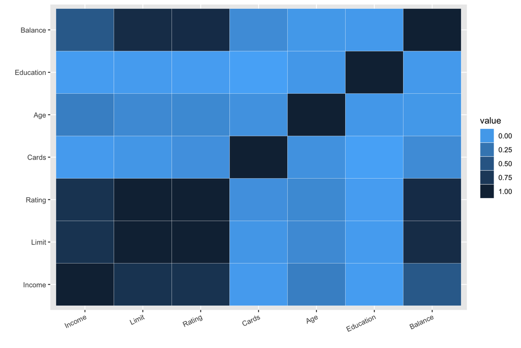

```r
ggplot(data = data.crd %>% select_if(is.numeric) %>% cor() %>% reshape2::melt(),
        aes(x = Var1 ,y = Var2, fill = value)) +
  geom_tile(color="white",size=0.1) +
  xlab("") +
  ylab("") +
  guides(fill = guide_legend(data.crdle = "Correlation")) +
  scale_fill_gradient( low = "#56B1F7", high = "#132B43") +     #lightblue to darkblue
  theme(axis.text.x = element_text(angle = 25, hjust = 1))
```

[figure not shown]

## 2. Criteria

We do not do model selection if we can avoid it. For example if there is solid science behind a model we may only need to estimate some unknown parameters.

Given a set of $p$ predictors, there will be $2^p$ (In this case there are $2^{10}$ = 1024) models.

Goal: build a parsimonious (simple) model which predicts the response as “accurately” as possible. **But how do we define accuracy?**

- If we use $RSS$ as a criterion, then the best model would be using all variables! **Do you remember why?**

```r
fit0 <- lm(Balance~.,data.crd)
summary(fit0)
```

```
##
## Call:
## lm(formula = Balance ~ ., data = data.crd)
##
## Residuals:
##     Min      1Q  Median      3Q     Max
## -161.64  -77.70  -13.49   53.98  318.20
##
## Coefficients:
##                      Estimate Std. Error t value Pr(>|t|)
## (Intercept)        -479.20787   35.77394 -13.395  < 2e-16 ***
## Income               -7.80310    0.23423 -33.314  < 2e-16 ***
## Limit                 0.19091    0.03278   5.824 1.21e-08 ***
## Rating                1.13653    0.49089   2.315   0.0211 *
## Cards                17.72448    4.34103   4.083 5.40e-05 ***
## Age                  -0.61391    0.29399  -2.088   0.0374 *
## Education            -1.09886    1.59795  -0.688   0.4921
## GenderFemale        -10.65325    9.91400  -1.075   0.2832
## StudentYes          425.74736   16.72258  25.459  < 2e-16 ***
## MarriedYes           -8.53390   10.36287  -0.824   0.4107
## EthnicityAsian       16.80418   14.11906   1.190   0.2347
## EthnicityCaucasian   10.10703   12.20992   0.828   0.4083
## ---
## Signif. codes:  0 '***' 0.001 '**' 0.01 '*' 0.05 '.' 0.1 ' ' 1
##
## Residual standard error: 98.79 on 388 degrees of freedom
## Multiple R-squared:  0.9551, Adjusted R-squared:  0.9538
## F-statistic: 750.3 on 11 and 388 DF,  p-value: < 2.2e-16
```

Remarks:

1. It is hard to interpret the model due to collinearity.
2. However, we can still use this model to do prediction.
3. Would the model with all the predictors whose `p-value` < .05 be the “best” one?

**Answer: Not necessarily the case!**

### Criterion of accuracy

Most often a model whose prediction error is small tends to also return a set of reasonable variables. By prediction error we mean:

$$\text{Prediction Error} = E(y- \hat
y_x)^2$$
The above is the sum of prediction errors for all the $x_i's$ in our data.

#### 1. Mean Squared Error (MSE)

$$MSE = \frac{1}{n} \sum_{i=1}^{n}
(\hat{y_i} - {y_i})^{2}$$
MSE is simple but it does not give us a good estimator for Prediction Error

#### 2. Mallows’s (Cp)

$$C_p=\frac{1}{n}(RSS+2d\cdot
\hat{\sigma}^2)$$

Note:

1. $d$: Number of the predictors in the model
2. $n$: Number of the observations in the dataset
3. $\hat{\sigma}^2$: Mean Squared Error (MSE) from the full model

**Fact:** If the full model is true, $C_p$ is an unbiased estimator of average prediction errors, namely $\frac{1}{n} \sum_{i=1}^{n} E(y_i|x_i - \hat y_i)^2$ (differ by some fixed quantity).

4. $C_p$ might be defined differently, but it will not affect the final model chosen.
5. $C_p$ will not always decrease as a function of d!
6. We may choose a model with smallest (or nearly smallest) $C_p$.

### Other criteria

#### 1. Akaike Information Criterion (AIC)

$$AIC=2k-2\ln(\hat{L})$$

- $k$: Number of estimated parameters
- $\hat{L}$: maximum value of the likelihood function for the model
- It is equivalent to $C_p$ in this setup.
- Notion of likelihood function

#### 2. Bayesian Information Criterion (BIC)

$$BIC=\ln(n)k-2\ln(\hat{L})$$

- $k$: Number of free parameters to be estimated
- $n$: Number of the observations in the dataset
- $\hat{L}$: maximum value of the likelihood function for the model
- It tends to output smaller models
- The `leaps` package outputs an alternative form of $BIC$

## 3. Model Building

### All Subsets

1. Given a model size $d$, find the one with min RSS, then compute its $Cp$.
2. Min $Cp$ (or $BIC$) to obtain the final model or use elbow rule!
3. Elbow: the point where the scree plot is leveling off.
4. Package `leaps`: `regsubsets()` does the job

#### Regsubsets

Let’s now try to select a good model. We will use the library `leaps`, which gives us model selection functions. It will output the best submodel within each model size together with `rsq`, `rss`, `adjr2`, `cp` and `bic`.

All subset selection: for each model size, report the one with the smallest RSS.

Pro: identify the “best” model.

Con: computation expensive. In our example: $2^{10}$=1024 models.

```r
fit.exh <- regsubsets(Balance ~., data.crd, nvmax=11, method="exhaustive")
```

The default settings:

- nvmax=8
- method=c(“exhaustive”, “backward”, “forward”, “seqrep”), “exhaustive” is the default setting.
- nbest=1: output candidate models whose RSS’s are similar.

```r
names(fit.exh)
```

```
##  [1] "np"        "nrbar"     "d"         "rbar"      "thetab"    "first"
##  [7] "last"      "vorder"    "tol"       "rss"       "bound"     "nvmax"
## [13] "ress"      "ir"        "nbest"     "lopt"      "il"        "ier"
## [19] "xnames"    "method"    "force.in"  "force.out" "sserr"     "intercept"
## [25] "lindep"    "nullrss"   "nn"        "call"
```

List the model with the smallest RSS among each size of the model

```r
summary(fit.exh)
```

```
## Subset selection object
## Call: regsubsets.formula(Balance ~ ., data.crd, nvmax = 11, method = "exhaustive")
## 11 Variables  (and intercept)
##                    Forced in Forced out
## Income                 FALSE      FALSE
## Limit                  FALSE      FALSE
## Rating                 FALSE      FALSE
## Cards                  FALSE      FALSE
## Age                    FALSE      FALSE
## Education              FALSE      FALSE
## GenderFemale           FALSE      FALSE
## StudentYes             FALSE      FALSE
## MarriedYes             FALSE      FALSE
## EthnicityAsian         FALSE      FALSE
## EthnicityCaucasian     FALSE      FALSE
## 1 subsets of each size up to 11
## Selection Algorithm: exhaustive
##           Income Limit Rating Cards Age Education GenderFemale StudentYes
## 1  ( 1 )  " "    " "   "*"    " "   " " " "       " "          " "
## 2  ( 1 )  "*"    " "   "*"    " "   " " " "       " "          " "
## 3  ( 1 )  "*"    " "   "*"    " "   " " " "       " "          "*"
## 4  ( 1 )  "*"    "*"   " "    "*"   " " " "       " "          "*"
## 5  ( 1 )  "*"    "*"   "*"    "*"   " " " "       " "          "*"
## 6  ( 1 )  "*"    "*"   "*"    "*"   "*" " "       " "          "*"
## 7  ( 1 )  "*"    "*"   "*"    "*"   "*" " "       "*"          "*"
## 8  ( 1 )  "*"    "*"   "*"    "*"   "*" " "       "*"          "*"
## 9  ( 1 )  "*"    "*"   "*"    "*"   "*" " "       "*"          "*"
## 10  ( 1 ) "*"    "*"   "*"    "*"   "*" " "       "*"          "*"
## 11  ( 1 ) "*"    "*"   "*"    "*"   "*" "*"       "*"          "*"
##           MarriedYes EthnicityAsian EthnicityCaucasian
## 1  ( 1 )  " "        " "            " "
## 2  ( 1 )  " "        " "            " "
## 3  ( 1 )  " "        " "            " "
## 4  ( 1 )  " "        " "            " "
## 5  ( 1 )  " "        " "            " "
## 6  ( 1 )  " "        " "            " "
## 7  ( 1 )  " "        " "            " "
## 8  ( 1 )  " "        "*"            " "
## 9  ( 1 )  "*"        "*"            " "
## 10  ( 1 ) "*"        "*"            "*"
## 11  ( 1 ) "*"        "*"            "*"
```

```r
f.e <- summary(fit.exh)
names(f.e)
```

```
## [1] "which"  "rsq"    "rss"    "adjr2"  "cp"     "bic"    "outmat" "obj"
```

Let’s look at the `which` table

```r
f.e$which
```

```
##    (Intercept) Income Limit Rating Cards   Age Education GenderFemale
## 1         TRUE  FALSE FALSE   TRUE FALSE FALSE     FALSE        FALSE
## 2         TRUE   TRUE FALSE   TRUE FALSE FALSE     FALSE        FALSE
## 3         TRUE   TRUE FALSE   TRUE FALSE FALSE     FALSE        FALSE
## 4         TRUE   TRUE  TRUE  FALSE  TRUE FALSE     FALSE        FALSE
## 5         TRUE   TRUE  TRUE   TRUE  TRUE FALSE     FALSE        FALSE
## 6         TRUE   TRUE  TRUE   TRUE  TRUE  TRUE     FALSE        FALSE
## 7         TRUE   TRUE  TRUE   TRUE  TRUE  TRUE     FALSE         TRUE
## 8         TRUE   TRUE  TRUE   TRUE  TRUE  TRUE     FALSE         TRUE
## 9         TRUE   TRUE  TRUE   TRUE  TRUE  TRUE     FALSE         TRUE
## 10        TRUE   TRUE  TRUE   TRUE  TRUE  TRUE     FALSE         TRUE
## 11        TRUE   TRUE  TRUE   TRUE  TRUE  TRUE      TRUE         TRUE
##    StudentYes MarriedYes EthnicityAsian EthnicityCaucasian
## 1       FALSE      FALSE          FALSE              FALSE
## 2       FALSE      FALSE          FALSE              FALSE
## 3        TRUE      FALSE          FALSE              FALSE
## 4        TRUE      FALSE          FALSE              FALSE
## 5        TRUE      FALSE          FALSE              FALSE
## 6        TRUE      FALSE          FALSE              FALSE
## 7        TRUE      FALSE          FALSE              FALSE
## 8        TRUE      FALSE           TRUE              FALSE
## 9        TRUE       TRUE           TRUE              FALSE
## 10       TRUE       TRUE           TRUE               TRUE
## 11       TRUE       TRUE           TRUE               TRUE
```

The row indicates the number of variables in the model with the smallest RSS. For example, if we want the best model with only one variable, then `Rating` is the best predictors. For two variables, `Rating` and `Income` are the best predictors.

We can see the value for each selection criterion. For example, let’s look at $R^2$

```r
data.frame(variables=(1:length(f.e$rsq)), r_squared=f.e$rsq)
```

```
##    variables r_squared
## 1          1 0.7458484
## 2          2 0.8751179
## 3          3 0.9498788
## 4          4 0.9535800
## 5          5 0.9541606
## 6          6 0.9546879
## 7          7 0.9548167
## 8          8 0.9548880
## 9          9 0.9549636
## 10        10 0.9550468
## 11        11 0.9551016
```

Notice that as we increase the number of variables, $R^2$ increases. Let’s now look at all the criterion options.

```r
data.frame(variables = (1:length(f.e$rsq)),
           r_squared = f.e$rsq,
           rss = f.e$rss,
           bic = f.e$bic,
           cp = f.e$cp)
```

```
##    variables r_squared      rss        bic          cp
## 1          1 0.7458484 21435122  -535.9468 1800.308406
## 2          2 0.8751179 10532541  -814.1798  685.196514
## 3          3 0.9498788  4227219 -1173.3585   41.133867
## 4          4 0.9535800  3915058 -1198.0527   11.148910
## 5          5 0.9541606  3866091 -1197.0957    8.131573
## 6          6 0.9546879  3821620 -1195.7321    5.574883
## 7          7 0.9548167  3810759 -1190.8790    6.462042
## 8          8 0.9548880  3804746 -1185.5192    7.845931
## 9          9 0.9549636  3798367 -1180.1989    9.192355
## 10        10 0.9550468  3791345 -1174.9476   10.472883
## 11        11 0.9551016  3786730 -1169.4433   12.000000
```

Regardless which criterion to be used, given a fixed number of predictors, we will have the same set of covariates which achieves the min value of `RSS`.

```r
coef(fit.exh, 6)
```

```
##  (Intercept)       Income        Limit       Rating        Cards          Age
## -493.7341870   -7.7950824    0.1936914    1.0911874   18.2118976   -0.6240560
##   StudentYes
##  425.6099369
```

```r
coef(fit.exh,7)
```

```
##  (Intercept)       Income        Limit       Rating        Cards          Age
## -488.6158695   -7.8036338    0.1936237    1.0940490   18.1091708   -0.6206538
## GenderFemale   StudentYes
##  -10.4531521  426.5812620
```

#### Compare different criterion

Let’s compare the different criteria.

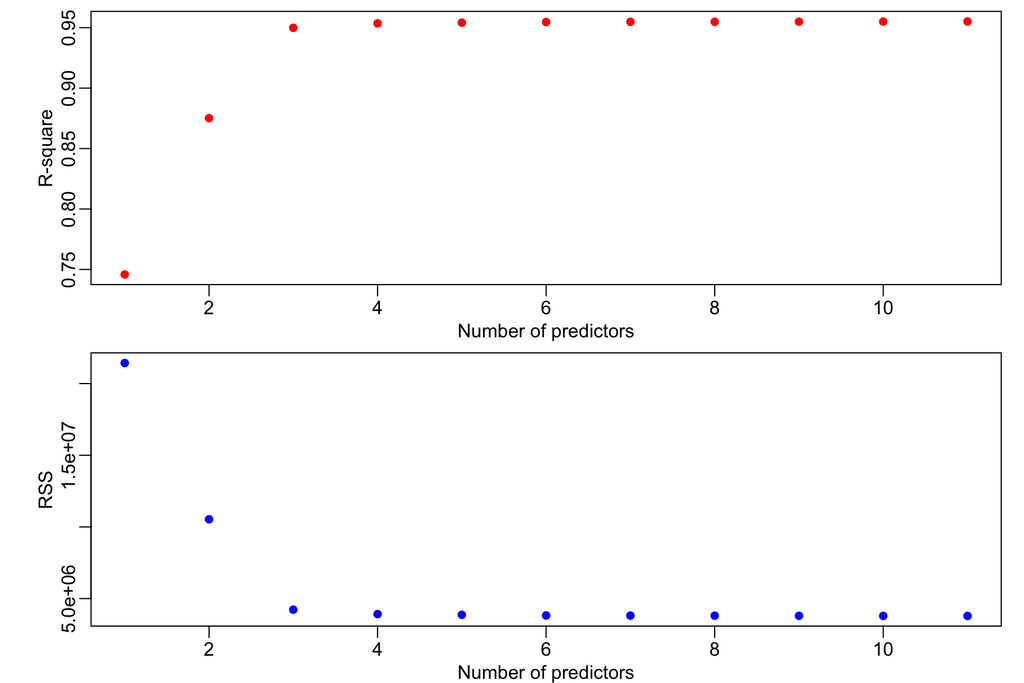

```r
par(mfrow=c(2,1), mar=c(2.5,4,0.5,1), mgp=c(1.5,0.5,0))
plot(f.e$rsq, xlab="Number of predictors", ylab="R-square", col="red", type="p", pch=16)
plot(f.e$rss, xlab="Number of predictors", ylab="RSS", col="blue", type="p", pch=16)
```

As expected $R^2$ increases as $d$ increases. $R^2$ or $RSS$ will not be good criteria to use in order to find a model which has the least average prediction squared error. $Cp$ or $BIC$ will be used.

Here are the plots of $Cp$ vs number of predictors. Similarly we have the plots of $BIC$ vs number of the predictors.

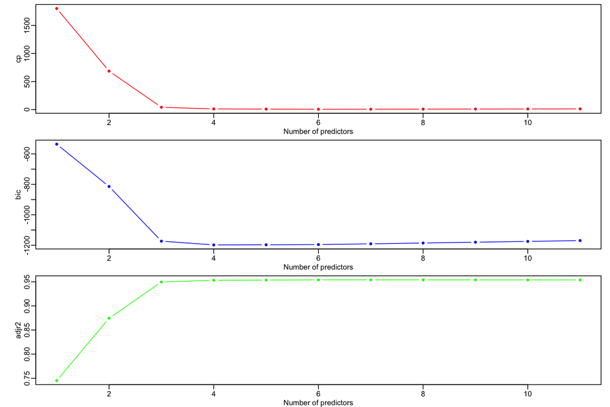

```r
par(mfrow=c(3,1), mar=c(2.5,4,0.5,1), mgp=c(1.5,0.5,0))     # Compare different criteria
plot(f.e$cp, xlab="Number of predictors",
     ylab="cp", col="red", type="b", pch=20)
plot(f.e$bic, xlab="Number of predictors",
     ylab="bic", col="blue", type="b", pch=20)
plot(f.e$adjr2, xlab="Number of predictors",
     ylab="adjr2", col="green", type="b", pch=20)
```

#### Optimal Model by Cp

Let’s locate the optimal model size by $Cp$.

```r
opt.size <- which.min(f.e$cp)
opt.size
```

```
## [1] 6
```

Now we look for the optimal variables selected

```r
fit.exh.var <- f.e$which # logic indicators which variables are in
fit.exh.var[opt.size,]  #fit.exh.var[5,]
```

```
##        (Intercept)             Income              Limit             Rating
##               TRUE               TRUE               TRUE               TRUE
##              Cards                Age          Education       GenderFemale
##               TRUE               TRUE              FALSE              FALSE
##         StudentYes         MarriedYes     EthnicityAsian EthnicityCaucasian
##               TRUE              FALSE              FALSE              FALSE
```

```r
colnames(fit.exh.var)[fit.exh.var[opt.size,]] # pull out the variable names
```

```
## [1] "(Intercept)" "Income"      "Limit"       "Rating"      "Cards"
## [6] "Age"         "StudentYes"
```

```r
fit.final <- lm(Balance ~ Income + Limit + Rating + Cards + Age + Student, data.crd)
# Student has two levels, so Student is same as StudentYes
summary(fit.final)
```

```
##
## Call:
## lm(formula = Balance ~ Income + Limit + Rating + Cards + Age +
##     Student, data = data.crd)
##
## Residuals:
##     Min      1Q  Median      3Q     Max
## -170.00  -77.85  -11.84   56.87  313.52
##
## Coefficients:
##               Estimate Std. Error t value Pr(>|t|)
## (Intercept) -493.73419   24.82476 -19.889  < 2e-16 ***
## Income        -7.79508    0.23342 -33.395  < 2e-16 ***
## Limit          0.19369    0.03238   5.981 4.98e-09 ***
## Rating         1.09119    0.48480   2.251   0.0250 *
## Cards         18.21190    4.31865   4.217 3.08e-05 ***
## Age           -0.62406    0.29182  -2.139   0.0331 *
## StudentYes   425.60994   16.50956  25.780  < 2e-16 ***
## ---
## Signif. codes:  0 '***' 0.001 '**' 0.01 '*' 0.05 '.' 0.1 ' ' 1
##
## Residual standard error: 98.61 on 393 degrees of freedom
## Multiple R-squared:  0.9547, Adjusted R-squared:  0.954
## F-statistic:  1380 on 6 and 393 DF,  p-value: < 2.2e-16
```

Note: there is no guarantee that all the var’s in the final model are significant at $\alpha =.05$ say.

When `d` is too large or in the situation `d` is even larger than `n`, it is impossible to search all subsets to find the least `RSS` model for each given number of predictors. One possibility is through `Forward Selection`.

Finally, we use ANOVA test to check whether this model is suitable.

```r
anova(fit.final,fit0)
```

```
## Analysis of Variance Table
##
## Model 1: Balance ~ Income + Limit + Rating + Cards + Age + Student
## Model 2: Balance ~ Income + Limit + Rating + Cards + Age + Education +
##     Gender + Student + Married + Ethnicity
##   Res.Df     RSS Df Sum of Sq     F Pr(>F)
## 1    393 3821620
## 2    388 3786730  5     34889 0.715 0.6125
```

### Forward Selection

```r
fit.forward <- regsubsets(Balance ~., data.crd, nvmax=11, method="forward")
f.f <- summary(fit.forward)
f.f
```

```
## Subset selection object
## Call: regsubsets.formula(Balance ~ ., data.crd, nvmax = 11, method = "forward")
## 11 Variables  (and intercept)
##                    Forced in Forced out
## Income                 FALSE      FALSE
## Limit                  FALSE      FALSE
## Rating                 FALSE      FALSE
## Cards                  FALSE      FALSE
## Age                    FALSE      FALSE
## Education              FALSE      FALSE
## GenderFemale           FALSE      FALSE
## StudentYes             FALSE      FALSE
## MarriedYes             FALSE      FALSE
## EthnicityAsian         FALSE      FALSE
## EthnicityCaucasian     FALSE      FALSE
## 1 subsets of each size up to 11
## Selection Algorithm: forward
##           Income Limit Rating Cards Age Education GenderFemale StudentYes
## 1  ( 1 )  " "    " "   "*"    " "   " " " "       " "          " "
## 2  ( 1 )  "*"    " "   "*"    " "   " " " "       " "          " "
## 3  ( 1 )  "*"    " "   "*"    " "   " " " "       " "          "*"
## 4  ( 1 )  "*"    "*"   "*"    " "   " " " "       " "          "*"
## 5  ( 1 )  "*"    "*"   "*"    "*"   " " " "       " "          "*"
## 6  ( 1 )  "*"    "*"   "*"    "*"   "*" " "       " "          "*"
## 7  ( 1 )  "*"    "*"   "*"    "*"   "*" " "       "*"          "*"
## 8  ( 1 )  "*"    "*"   "*"    "*"   "*" " "       "*"          "*"
## 9  ( 1 )  "*"    "*"   "*"    "*"   "*" " "       "*"          "*"
## 10  ( 1 ) "*"    "*"   "*"    "*"   "*" " "       "*"          "*"
## 11  ( 1 ) "*"    "*"   "*"    "*"   "*" "*"       "*"          "*"
##           MarriedYes EthnicityAsian EthnicityCaucasian
## 1  ( 1 )  " "        " "            " "
## 2  ( 1 )  " "        " "            " "
## 3  ( 1 )  " "        " "            " "
## 4  ( 1 )  " "        " "            " "
## 5  ( 1 )  " "        " "            " "
## 6  ( 1 )  " "        " "            " "
## 7  ( 1 )  " "        " "            " "
## 8  ( 1 )  " "        "*"            " "
## 9  ( 1 )  "*"        "*"            " "
## 10  ( 1 ) "*"        "*"            "*"
## 11  ( 1 ) "*"        "*"            "*"
```

For any fixed number, the model selected from `All Subset Selection` will have larger $R^2$ (or smaller $RSS$) than that from `Forward Selection` and **WHY?**

```r
plot(f.f$rsq, ylab="rsq", col="red", type="b", pch=16,
     xlab="Forward Selection")
lines(f.e$rsq, ylab="rsq", col="blue", type="b", pch=16,
   xlab="All Subset Selection")
```

[output not shown]

If we decided to use a model with 6 predictors by forward selection, here it is:

```r
coef(fit.forward, which.min(f.f$cp))
```

```
##  (Intercept)       Income        Limit       Rating        Cards          Age
## -493.7341870   -7.7950824    0.1936914    1.0911874   18.2118976   -0.6240560
##   StudentYes
##  425.6099369
```

In this data, forward selection, with Mallow’s Cp Criterion happens to select the same model as best subset selection does.

### Backward Selection

Especially useful when `p` is large (still smaller than `n`)!

```r
fit.backward <- regsubsets(Balance ~., data.crd, nvmax=11, method="backward")
f.b <- summary(fit.backward)
```

```r
coef(fit.backward, which.min(f.b$cp))
```

```
##  (Intercept)       Income        Limit       Rating        Cards          Age
## -493.7341870   -7.7950824    0.1936914    1.0911874   18.2118976   -0.6240560
##   StudentYes
##  425.6099369
```

### Comparsion

At any given number, the predictors selected may vary depending on the selection method.

**Exhaustive**

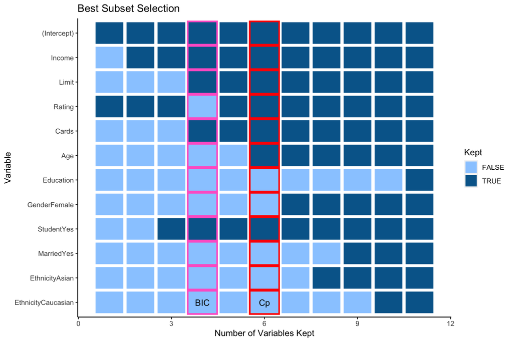

4 Variables: `Income`, `Limit`, `Cards`, `Student`

**Forward Selection**

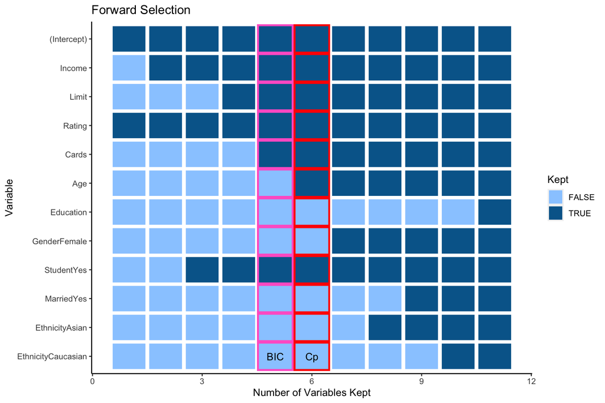

4 Variables: `Income`, `Limit`, `Rating`, `Student`

Notice that Exhaustive and Forward selection give us different variables when we look for the best 4 variables.

**Backward Selection**

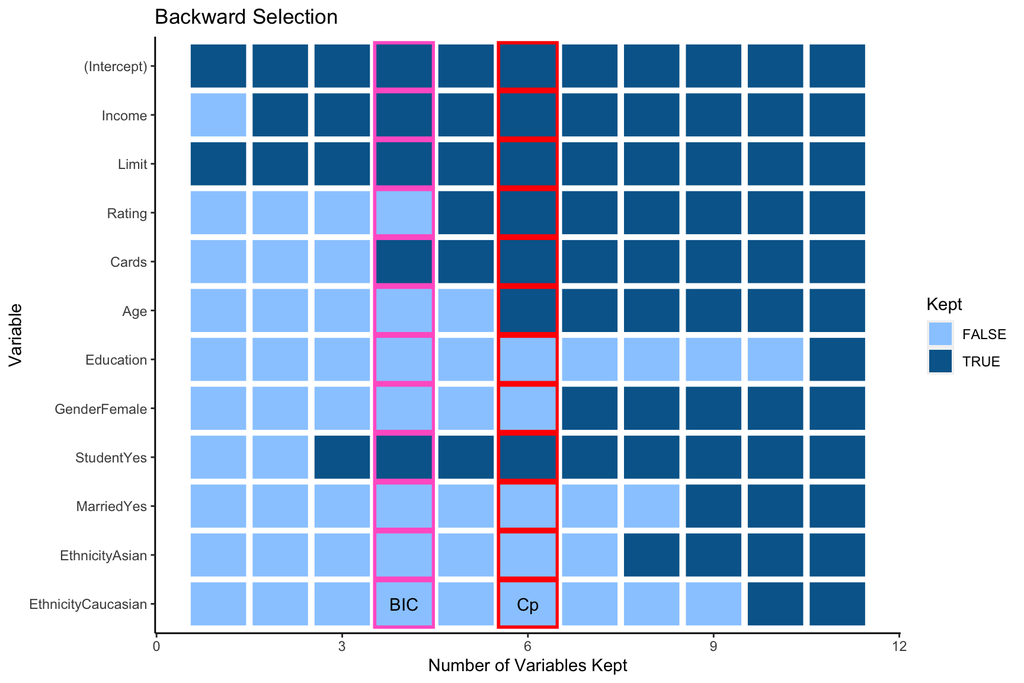

4 Variables: `Income`, `Limit`, `Cards`, `Student`

**Remark:** Let’s compare three selection methods. Can you tell for sure at a given d which method will give the least Mallow’s Cp value?

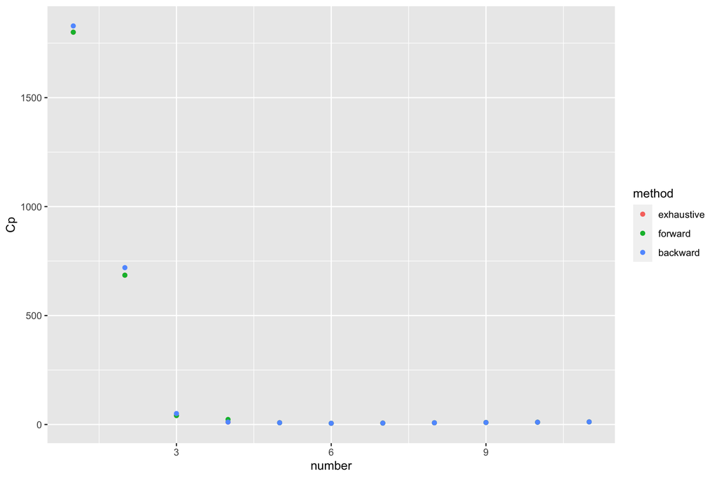

```r
res.cp <- data.frame(number = 1:11, exhaustive = f.e$cp, forward = f.f$cp, backward = f.b$cp)
res.cp <- reshape::melt(res.cp,id.vars = "number")
colnames(res.cp) <- c("number","method","Cp")
ggplot(res.cp, aes(x = number, y = Cp)) +
  geom_point(aes(col=method))
```

## 4. Findings and Reports

### Final model

Here we use final model selected by best subset selection.

```r
fit.final <- lm(Balance ~ Income + Limit + Rating + Cards + Age + Student, data.crd)
summary(fit.final)
```

```
##
## Call:
## lm(formula = Balance ~ Income + Limit + Rating + Cards + Age +
##     Student, data = data.crd)
##
## Residuals:
##     Min      1Q  Median      3Q     Max
## -170.00  -77.85  -11.84   56.87  313.52
##
## Coefficients:
##               Estimate Std. Error t value Pr(>|t|)
## (Intercept) -493.73419   24.82476 -19.889  < 2e-16 ***
## Income        -7.79508    0.23342 -33.395  < 2e-16 ***
## Limit          0.19369    0.03238   5.981 4.98e-09 ***
## Rating         1.09119    0.48480   2.251   0.0250 *
## Cards         18.21190    4.31865   4.217 3.08e-05 ***
## Age           -0.62406    0.29182  -2.139   0.0331 *
## StudentYes   425.60994   16.50956  25.780  < 2e-16 ***
## ---
## Signif. codes:  0 '***' 0.001 '**' 0.01 '*' 0.05 '.' 0.1 ' ' 1
##
## Residual standard error: 98.61 on 393 degrees of freedom
## Multiple R-squared:  0.9547, Adjusted R-squared:  0.954
## F-statistic:  1380 on 6 and 393 DF,  p-value: < 2.2e-16
```

### Final Report

Income = 50, Limit = 4000, Rating = 500, Age = 25, Cards = 2, Student = Yes

1. We first make a dataframe:

```r
customer <- data.crd[1,] # Get the right format and the variable names
customer[1,] <- rep(NA,11)
customer$Income <- 50
customer$Limit <- 4000
customer$Rating <- 500
customer$Age <- 25
customer$Cards <- 2
customer$Student <- as.factor("Yes")
customer
```

```
##   Income Limit Rating Cards Age Education Gender Student Married Ethnicity
## 1     50  4000    500     2  25        NA   <NA>     Yes    <NA>      <NA>
##   Balance
## 1      NA
```

2. Get a 95% CI for the mean balances for all such customers

```r
customer.m <- predict(fit.final, customer, interval="confidence", se.fit=TRUE)
customer.m
```

```
## $fit
##        fit      lwr      upr
## 1 883.3034 692.8644 1073.742
##
## $se.fit
## [1] 96.8653
##
## $df
## [1] 393
##
## $residual.scale
## [1] 98.61148
```

3. Get a 95% Prediction Interval of the balance for the customer

```r
customer.c <- predict(fit.final, customer, interval="prediction", se.fit=TRUE)
customer.c
```

```
## $fit
##        fit      lwr      upr
## 1 883.3034 611.5436 1155.063
##
## $se.fit
## [1] 96.8653
##
## $df
## [1] 393
##
## $residual.scale
## [1] 98.61148
```

### Summary

1. You should always do EDA. By looking at your data, you might be able to identify some candidate variables and to find problems such as colinearity, non-linearity, missing data, and outliers. If you identify any problem, and fix it, your model will improve. `Pairwise scatter plots`, `Correlation heatmaps`, and `Correlation tables` are very useful in EDA.
2. There are different criteria for measuring how good a `fit` is. We recommend to use `Cp` and `BIC`. We will introduce more methods later.
3. When building a model, you can use All Subsets, which searches for all possible combinations. When you have many variables, this is computationally expensive. You have two other options: Forward and Backward Selection. They each have their advantages and disadvantages.
4. After building your model, you should always run model diagnostics to identify issues such as: auto-correlated residuals, violations of normality or equal variance of residuals. If you find any of these problems, it’s very likely that you might need to do some variable transformation. Before writing a report, make sure that the model makes sense to you.

## 4. Appendix

### Appendix I: Starting with a collection of predictors

1. If you want to only start with a collection of predictors, you may use the usual formula: $y =x_1+x_2$ inside the regsubsets. For example if you only want to search a best model using Limit, Rating, Cards, Age, Student and log(Income), you may do the following:

```r
summary(regsubsets(Balance ~ Limit + Rating + Cards + Age + Student + log(Income), data.crd))
```

```
## Subset selection object
## Call: regsubsets.formula(Balance ~ Limit + Rating + Cards + Age + Student +
##     log(Income), data.crd)
## 6 Variables  (and intercept)
##             Forced in Forced out
## Limit           FALSE      FALSE
## Rating          FALSE      FALSE
## Cards           FALSE      FALSE
## Age             FALSE      FALSE
## StudentYes      FALSE      FALSE
## log(Income)     FALSE      FALSE
## 1 subsets of each size up to 6
## Selection Algorithm: exhaustive
##          Limit Rating Cards Age StudentYes log(Income)
## 1  ( 1 ) " "   "*"    " "   " " " "        " "
## 2  ( 1 ) " "   "*"    " "   " " " "        "*"
## 3  ( 1 ) "*"   " "    " "   " " "*"        "*"
## 4  ( 1 ) "*"   " "    "*"   " " "*"        "*"
## 5  ( 1 ) "*"   " "    "*"   "*" "*"        "*"
## 6  ( 1 ) "*"   "*"    "*"   "*" "*"        "*"
```

### Appendix II Restricting size of possible models

2. We could also restrict the maximum possible model size so that we only search the best models up to `nvmax`. This is useful when `p` is large!

```r
summary(regsubsets(Balance ~ ., data.crd, nvmax=5, method="exhaustive"))
```

```
## Subset selection object
## Call: regsubsets.formula(Balance ~ ., data.crd, nvmax = 5, method = "exhaustive")
## 11 Variables  (and intercept)
##                    Forced in Forced out
## Income                 FALSE      FALSE
## Limit                  FALSE      FALSE
## Rating                 FALSE      FALSE
## Cards                  FALSE      FALSE
## Age                    FALSE      FALSE
## Education              FALSE      FALSE
## GenderFemale           FALSE      FALSE
## StudentYes             FALSE      FALSE
## MarriedYes             FALSE      FALSE
## EthnicityAsian         FALSE      FALSE
## EthnicityCaucasian     FALSE      FALSE
## 1 subsets of each size up to 5
## Selection Algorithm: exhaustive
##          Income Limit Rating Cards Age Education GenderFemale StudentYes
## 1  ( 1 ) " "    " "   "*"    " "   " " " "       " "          " "
## 2  ( 1 ) "*"    " "   "*"    " "   " " " "       " "          " "
## 3  ( 1 ) "*"    " "   "*"    " "   " " " "       " "          "*"
## 4  ( 1 ) "*"    "*"   " "    "*"   " " " "       " "          "*"
## 5  ( 1 ) "*"    "*"   "*"    "*"   " " " "       " "          "*"
##          MarriedYes EthnicityAsian EthnicityCaucasian
## 1  ( 1 ) " "        " "            " "
## 2  ( 1 ) " "        " "            " "
## 3  ( 1 ) " "        " "            " "
## 4  ( 1 ) " "        " "            " "
## 5  ( 1 ) " "        " "            " "
```

```r
#We restrict a model with no more than nvmax=5 variables.
```

### Appendix II `force.in`

3. Sometimes, we want to build model based on some already selected variables. Hence, we use `force.in` to force some variables in the model

```r
colnames(data.crd)[8]
```

```
## [1] "Student"
```

```r
fit.force.in <- regsubsets(Balance ~., data.crd, nvmax=11, method="forward", force.in=8+1)

# We need to specify the index. Note: the first one is the intercept.
summary(fit.force.in)
```

[output not shown]